# Seattle Airbnb Dataset

This article is to discuss the Data Science process and communication with stakeholders,to share insights and solutions to business problems derived from data. I chose dataset "Airbnb Seattle data".  
The article then proceeds to ask questions and interpret the results of the data analysis.

##### About Airbnb:

Airbnb, Inc. is an internet-based platform that connects people seeking lodging or tourism experiences with individuals offering them, mainly homestays. The company operates as a middleman and does not possess any of the real estate listings or organize events. Instead, it earns commissions from each booking facilitated through its platform. Airbnb, Inc. is headquartered in San Francisco, California, in the United States.

### The First Part of Exploration : Understandings of Price Seasonal and Usage trend

#### Question 1: Indicating the seasonal pattern of Price and Accommodation Usage trend?

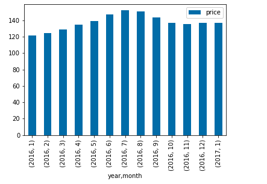

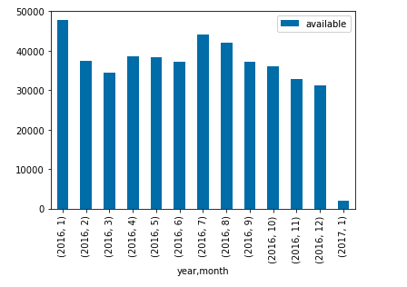

#### Question 2: Which neighborhoods the price reach the highest and lowest in a year?

By investigating the listings dataset, it is revealed that the Southeast Mangolia neighborhood had the highest prices, with Portage Bay, Westlake, West Queen Anne, and Montlake following close behind. On the other hand, the lowest prices were found in Rainier Beach, North and South Delridge, Georgetown, and Olympic Hills neighborhoods.

##### Top 5 with the highest average price:

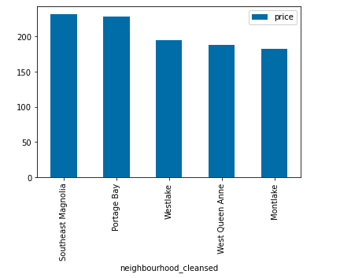

##### 5 neighborhoods with lowest average price:

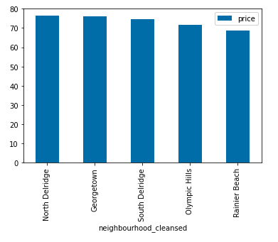

#### Question 3: How does property types within neighborhoods impact price for the most expensive neighborhoods and most common property types?

The main focus of the analysis is to examine the housing market in the highest-priced neighborhoods identified in the previous analysis, with particular attention paid to houses and apartments. These two types of properties constitute a significant proportion of the housing market and are often the most sought-after by potential renters or buyers.

Additionally, it was observed that the prices of both houses and apartments in Westlake were similar.

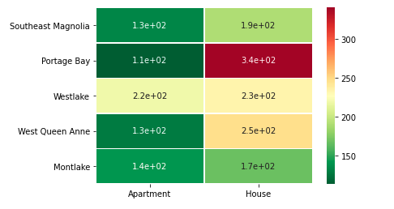

### The Second Part of Exploration : Price Prediction

#### Question 4: Can we predict price for a given listing? What factors of the listing correlate best for predicting price?

After cleansing the data, we using the dataset to predict the price for the given listings. The analysis involved modeling the data, which resulted in a coefficient of 0.62 for both the training and test data sets. Further coefficient analysis revealed that the most significant factors influencing the price were the combination of host details and descriptive information about the listing, including host_name, has_availability, transit, space, host_about, notes, and neighborhood_overview, among others. These variables had a considerable impact on the price of the property.

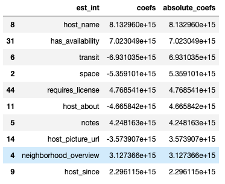